# Week2

Katherine Shim

November 21, 2018

### Caret functionality

- Preprocessing
  - `preProcess`
- Data splitting
  - `createDataPartition`
  - `createResample`
  - `createTimeSlices`
- Training/testing functions
  - `train`
  - `predict`
- Model comparison
  - ‘confusionMatrix’

### ML Algorithms in R

- Linear discriminant analysis
- Regression
- Naive Bayes
- Support vector machines
- Classification and regression trees
- Random forests
- Boosting

### Example: SPAM DATA

```r
# Data splitting
data(spam)
# Put 75% of data in training set, rest in testing
inTrain <- createDataPartition(y=spam$type, p=0.75, list=FALSE)
training <- spam[inTrain,]
testing <- spam[-inTrain,]
#Fit a model
set.seed(32343)
modelFit <- train(type~., data=training, method="glm")
modelFit
```

```
## Generalized Linear Model
##
## 3451 samples
##   57 predictor
##    2 classes: 'nonspam', 'spam'
##
## No pre-processing
## Resampling: Bootstrapped (25 reps)
## Summary of sample sizes: 3451, 3451, 3451, 3451, 3451, 3451, ...
## Resampling results:
##
##   Accuracy   Kappa
##   0.9167869  0.8240576
```

```r
#Final model and prediction
modelFit$finalModel
```

```
##
## Call:  NULL
##
## Coefficients:
##       (Intercept)               make            address
##        -1.554e+00         -3.419e-01         -1.239e-01
##               all              num3d                our
##         8.984e-02          1.993e+00          5.658e-01
##              over             remove           internet
##         7.785e-01          2.147e+00          5.426e-01
##             order               mail            receive
##         5.382e-01          8.806e-02         -4.065e-01
##              will             people             report
##        -1.076e-01         -2.405e-03          1.538e-01
##         addresses               free           business
##         9.112e-01          9.298e-01          9.917e-01
##             email                you             credit
##         2.350e-01          4.755e-02          2.066e+00
##              your               font             num000
##         2.201e-01          1.849e-01          3.335e+00
##             money                 hp                hpl
##         2.667e-01         -2.061e+00         -5.863e-01
##            george             num650                lab
##        -1.818e+01          3.974e-01         -4.624e+00
##              labs             telnet             num857
##        -2.206e-01         -1.102e-01          6.034e+00
##              data             num415              num85
##        -7.913e-01          5.824e-01         -1.616e+00
##        technology            num1999              parts
##         7.590e-01          1.151e-01          1.012e+00
##                pm             direct                 cs
##        -9.412e-01         -2.157e-01         -4.278e+02
##           meeting           original            project
##        -2.778e+00         -1.120e+00         -2.327e+00
##                re                edu              table
##        -8.279e-01         -1.509e+00         -2.081e+00
##        conference      charSemicolon   charRoundbracket
##        -3.900e+00         -1.230e+00         -2.687e-01
## charSquarebracket    charExclamation         charDollar
##        -1.557e+00          2.599e-01          5.204e+00
##          charHash         capitalAve        capitalLong
##         1.754e+00          5.635e-02          6.327e-03
##      capitalTotal
##         1.053e-03
##
## Degrees of Freedom: 3450 Total (i.e. Null);  3393 Residual
## Null Deviance:       4628
## Residual Deviance: 1357  AIC: 1473
```

```r
predictions <- predict(modelFit, newdata=testing)
head(predictions)
```

```
## [1] spam spam spam spam spam spam
## Levels: nonspam spam
```

```r
#Confusion Matrix
confusionMatrix(predictions, testing$type)
```

```
## Confusion Matrix and Statistics
##
##           Reference
## Prediction nonspam spam
##    nonspam     675   61
##    spam         22  392
##
##                Accuracy : 0.9278
##                  95% CI : (0.9113, 0.9421)
##     No Information Rate : 0.6061
##     P-Value [Acc > NIR] : < 2.2e-16
##
##                   Kappa : 0.8465
##  Mcnemar's Test P-Value : 3.032e-05
##
##             Sensitivity : 0.9684
##             Specificity : 0.8653
##          Pos Pred Value : 0.9171
##          Neg Pred Value : 0.9469
##              Prevalence : 0.6061
##          Detection Rate : 0.5870
##    Detection Prevalence : 0.6400
##       Balanced Accuracy : 0.9169
##
##        'Positive' Class : nonspam
##
```

### Data slicing

**Data splitting**

```r
data(spam)
# Put 75% of data in training set, rest in testing
inTrain <- createDataPartition(y=spam$type, p=0.75, list=FALSE)
training <- spam[inTrain,]
testing <- spam[-inTrain,]
```

**K-fold** Use for cross-validation

```r
set.seed(32323)
# Return the train set
folds_train <- createFolds(y=spam$type, k=10, list=TRUE, returnTrain = TRUE)
sapply(folds_train, length)
```

```
## Fold01 Fold02 Fold03 Fold04 Fold05 Fold06 Fold07 Fold08 Fold09 Fold10
##   4141   4140   4141   4142   4140   4142   4141   4141   4140   4141
```

```r
# Return the test set
folds_test <- createFolds(y=spam$type, k=10, list=TRUE, returnTrain = FALSE)
sapply(folds_test, length)
```

```
## Fold01 Fold02 Fold03 Fold04 Fold05 Fold06 Fold07 Fold08 Fold09 Fold10
##    460    459    460    460    460    460    460    460    461    461
```

```r
# Check the first 10 elements in the first fold of the training set
folds_train[[1]][1:10]
```

```
##  [1]  1  2  3  4  5  6  7  8  9 10
```

```r
# Check the first 10 elements in the first fold of the testing set
folds_test[[1]][1:10]
```

```
##  [1]  19  21  51  54  63  69  72  80  92 102
```

**Resampling** Use for cross-validation

```r
set.seed(32323)
sample <- createResample(y=spam$type, times=10, list=TRUE)
sapply(sample, length)
```

```
## Resample01 Resample02 Resample03 Resample04 Resample05 Resample06
##       4601       4601       4601       4601       4601       4601
## Resample07 Resample08 Resample09 Resample10
##       4601       4601       4601       4601
```

```r
# Check the first 10 elements in the first sample
sample[[1]][1:10]
```

```
##  [1]  1  2  3  3  3  5  5  7  8 12
```

**Time Slices** Use for cross-validation

```r
set.seed(32323)
tme <- 1:1000
# 20 data points in train, 10 data points in test
timeslice <- createTimeSlices(y=tme, initialWindow=20, horizon=10)
timeslice$train[[1]]
```

```
##  [1]  1  2  3  4  5  6  7  8  9 10 11 12 13 14 15 16 17 18 19 20
```

```r
timeslice$test[[1]]
```

```
##  [1] 21 22 23 24 25 26 27 28 29 30
```

### trainControl

```r
args(trainControl)
```

```
## function (method = "boot", number = ifelse(grepl("cv", method),
##     10, 25), repeats = ifelse(grepl("[d_]cv$", method), 1, NA),
##     p = 0.75, search = "grid", initialWindow = NULL, horizon = 1,
##     fixedWindow = TRUE, skip = 0, verboseIter = FALSE, returnData = TRUE,
##     returnResamp = "final", savePredictions = FALSE, classProbs = FALSE,
##     summaryFunction = defaultSummary, selectionFunction = "best",
##     preProcOptions = list(thresh = 0.95, ICAcomp = 3, k = 5,
##         freqCut = 95/5, uniqueCut = 10, cutoff = 0.9), sampling = NULL,
##     index = NULL, indexOut = NULL, indexFinal = NULL, timingSamps = 0,
##     predictionBounds = rep(FALSE, 2), seeds = NA, adaptive = list(min = 5,
##         alpha = 0.05, method = "gls", complete = TRUE), trim = FALSE,
##     allowParallel = TRUE)
## NULL
```

- `method`
  - `boot` = bootstrapping
  - `boot632` = bootstrapping with adjustment. Multiple samples are repeatedly resampled during bootstrap subsampling. This adjustment will reduce some of the bias due to that fact.
  - `cv` = cross validation
  - `repeatedcv` = repeated cross validation
  - `LOOCV` = leave one out cross validation
- `number`
  - Number of subsamples to take for bootstrap and cross validations
- `repeats`
  - Number of times to repeat subsampling such as cv.
- `seeds`
  - It is often useful to set an overall seed
  - You can also set a seed for each resample
  - Seeding each resample is useful for parallel fits

### Metric options

**Continuous outcomes**

- RMSE = Root mean squared error
- RSquared = $R^2$ from regression models

**Categorical outcomes**

- Accuracy = Fraction correct
- Kappa = A measure of concordance

### Plotting predictors

You need to plot the predictors upfront so you can see if there’s any sort of weird behavior of those variables.

```r
data(Wage)
summary(Wage)
```

```
##       year           age                     maritl           race
##  Min.   :2003   Min.   :18.00   1. Never Married: 648   1. White:2480
##  1st Qu.:2004   1st Qu.:33.75   2. Married      :2074   2. Black: 293
##  Median :2006   Median :42.00   3. Widowed      :  19   3. Asian: 190
##  Mean   :2006   Mean   :42.41   4. Divorced     : 204   4. Other:  37
##  3rd Qu.:2008   3rd Qu.:51.00   5. Separated    :  55
##  Max.   :2009   Max.   :80.00
##
##               education                     region
##  1. < HS Grad      :268   2. Middle Atlantic   :3000
##  2. HS Grad        :971   1. New England       :   0
##  3. Some College   :650   3. East North Central:   0
##  4. College Grad   :685   4. West North Central:   0
##  5. Advanced Degree:426   5. South Atlantic    :   0
##                           6. East South Central:   0
##                           (Other)              :   0
##            jobclass               health      health_ins      logwage
##  1. Industrial :1544   1. <=Good     : 858   1. Yes:2083   Min.   :3.000
##  2. Information:1456   2. >=Very Good:2142   2. No : 917   1st Qu.:4.447
##                                                            Median :4.653
##                                                            Mean   :4.654
##                                                            3rd Qu.:4.857
##                                                            Max.   :5.763
##
##       wage
##  Min.   : 20.09
##  1st Qu.: 85.38
##  Median :104.92
##  Mean   :111.70
##  3rd Qu.:128.68
##  Max.   :318.34
##
```

```r
# Put 70% of data in training set, rest in testing
inTrain <- createDataPartition(y=spam$type, p=0.7, list=FALSE)
training <- Wage[inTrain,]
testing <- Wage[-inTrain,]
dim(training); dim(testing)
```

```
## [1] 3222   11
```

```
## [1] 908  11
```

### Feature plot (caret package)

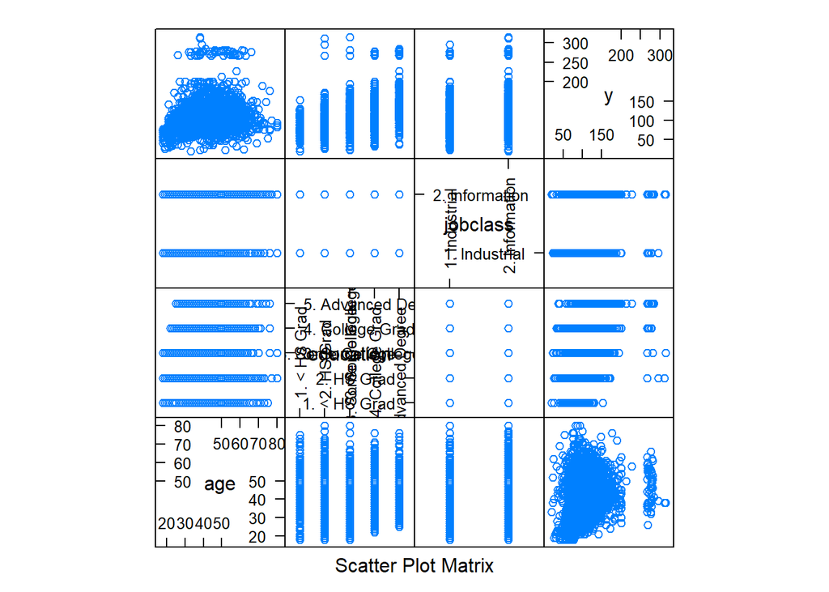

```r
featurePlot(x=training[,c("age","education","jobclass")], y = training$wage, plot="pairs")
```

### Qplot (ggplot2 package)

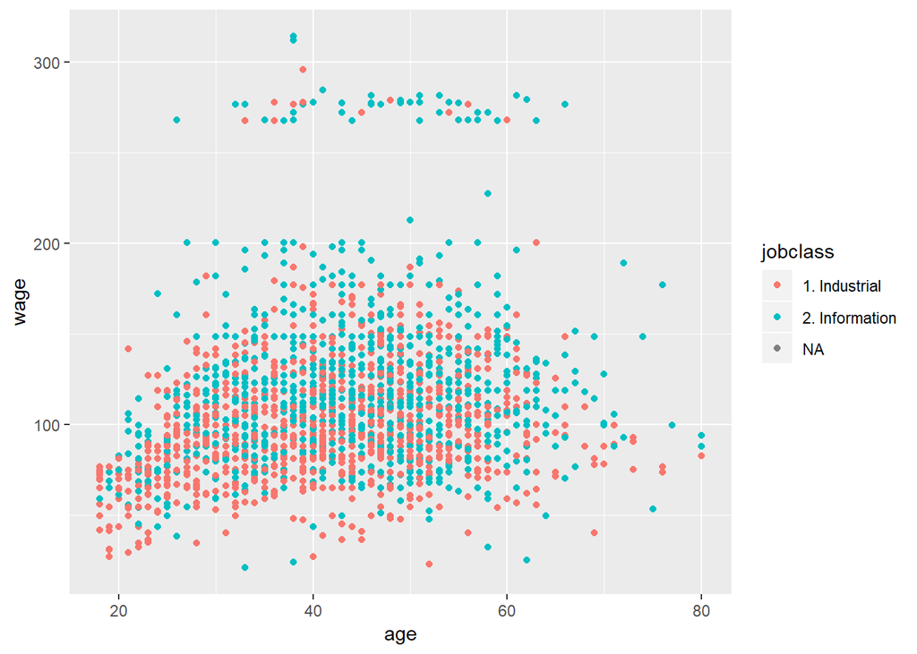

```r
qplot(age, wage, colour=jobclass, data=training)
```

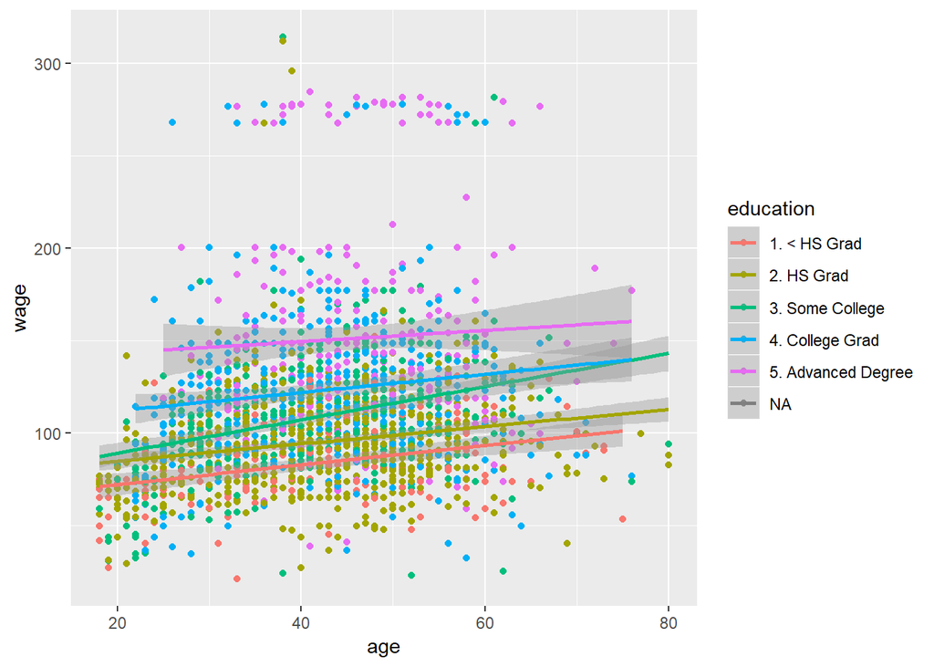

```r
#You can also add regression lines with smoothers
qq <- qplot(age, wage, colour=education, data=training)
qq+geom_smooth(method="lm", formula=y~x)
```

### cut2, making factors (Hmisc package)

```r
cutWage <- cut2(training$wage, g=3)
table(cutWage)
```

```
## cutWage
## [ 20.9, 91.7) [ 91.7,118.9) [118.9,314.3]
##           707           730           655
```

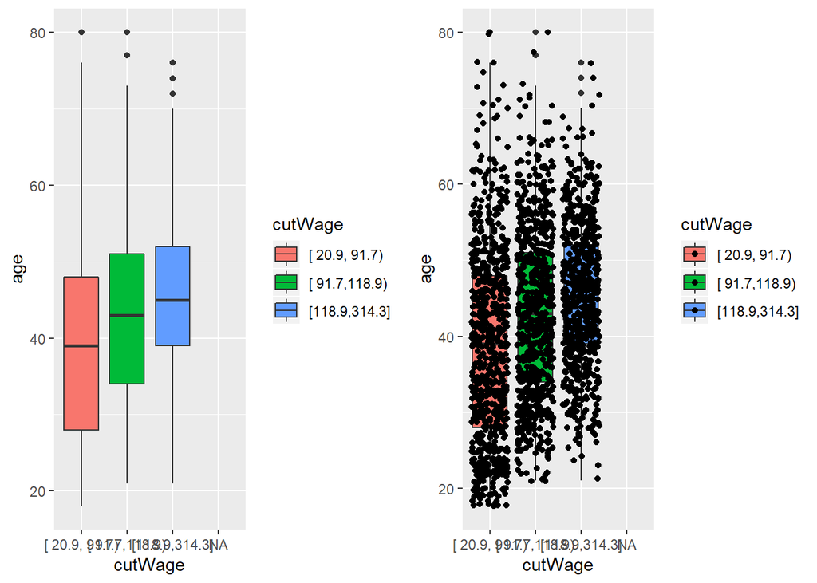

```r
#Now you can boxplot with cut2
p1 <- qplot(cutWage, age, data=training, fill=cutWage, geom=c("boxplot"))
#Boxplots with points overlayed
p2 <- qplot(cutWage, age, data=training, fill=cutWage, geom=c("boxplot", "jitter"))
grid.arrange(p1, p2, ncol=2)
```

### Tables

```r
t1 <- table(cutWage, training$jobclass)
t1
```

```
##
## cutWage         1. Industrial 2. Information
##   [ 20.9, 91.7)           448            259
##   [ 91.7,118.9)           376            354
##   [118.9,314.3]           257            398
```

```r
#You can get proportion of each group. Argument 1 is to indicate that you want proportion among rows. 2 for columns.
prop.table(t1,1)
```

```
##
## cutWage         1. Industrial 2. Information
##   [ 20.9, 91.7)     0.6336634      0.3663366
##   [ 91.7,118.9)     0.5150685      0.4849315
##   [118.9,314.3]     0.3923664      0.6076336
```

### Density plots

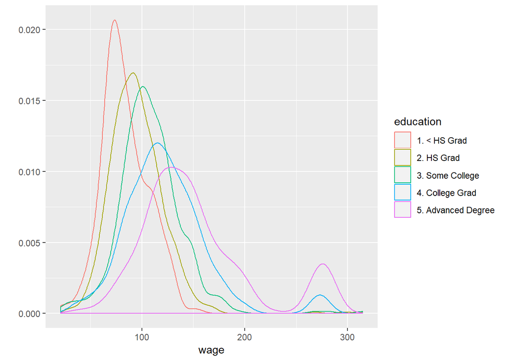

```r
qplot(wage, colour=education, data=training, geom="density")
```

### Basic preprocessing

- Sometimes predictors or distributions will be very strange, and need to do transformation to make them more useful for prediction algorithms.
- Useful for model based algorithms such as linear discriminate analysis, naive Bayes, linear regression and etc.

### Standardizing - manually

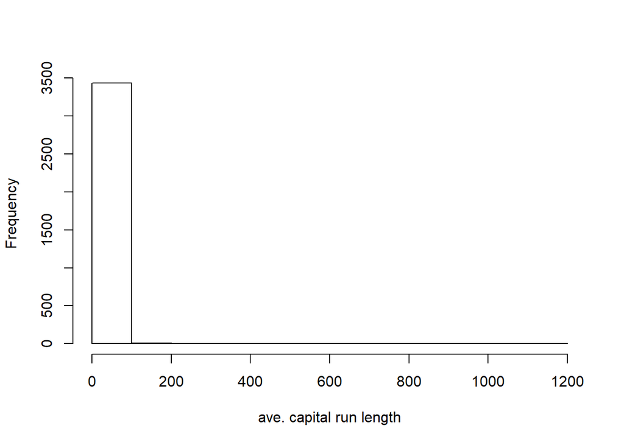

```r
data(spam)
inTrain <- createDataPartition(y=spam$type, p=0.75, list=FALSE)
training <- spam[inTrain,]
testing <- spam[-inTrain,]
hist(training$capitalAve, main="", xlab="ave. capital run length")
```

Data might be very skewed and need to preprocess.

```r
mean(training$capitalAve)
```

```
## [1] 5.679151
```

```r
sd(training$capitalAve)
```

```
## [1] 36.13015
```

We can see that standard deviation is very large. Hence ML algo can be tricked by this skewedness and high variability of sample. We can handle this issue with standardization.

```r
trainCapAve <- training$capitalAve
trainCapAveS <- (trainCapAve - mean(trainCapAve))/sd(trainCapAve)
mean(trainCapAveS)
```

```
## [1] 7.282726e-18
```

```r
sd(trainCapAveS)
```

```
## [1] 1
```

```r
testCapAve <- testing$capitalAve
testCapAveS <- (testCapAve-mean(trainCapAve))/sd(trainCapAve)
mean(testCapAveS)
```

```
## [1] -0.05399833
```

```r
sd(testCapAveS)
```

```
## [1] 0.2877794
```

### Standardizing - preProcess function

```r
#Omit 58th column because that's the outcome
preObj <- preProcess(training[,-58],method=c("center","scale"))
trainCapAveS <- predict(preObj,training[,-58])$capitalAve
mean(trainCapAveS)
```

```
## [1] 7.282726e-18
```

```r
sd(trainCapAveS)
```

```
## [1] 1
```

```r
#Apply the same preprocess object on testing set
testCapAveS <- predict(preObj,testing[,-58])$capitalAve
mean(testCapAveS)
```

```
## [1] -0.05399833
```

```r
sd(testCapAveS)
```

```
## [1] 0.2877794
```

### Standardizing - preProcess argument in train function

```r
set.seed(32343)
modelFit <- train(type ~.,data=training,
                  preProcess=c("center","scale"),method="glm")
modelFit
```

```
## Generalized Linear Model
##
## 3451 samples
##   57 predictor
##    2 classes: 'nonspam', 'spam'
##
## Pre-processing: centered (57), scaled (57)
## Resampling: Bootstrapped (25 reps)
## Summary of sample sizes: 3451, 3451, 3451, 3451, 3451, 3451, ...
## Resampling results:
##
##   Accuracy   Kappa
##   0.9175664  0.8258499
```

### Standardizing - Box-Cox transforms

Box cox transformation take continuous data and try to make them look like normally distributed data by estimating a specific set of parameters using maximum likelihood.

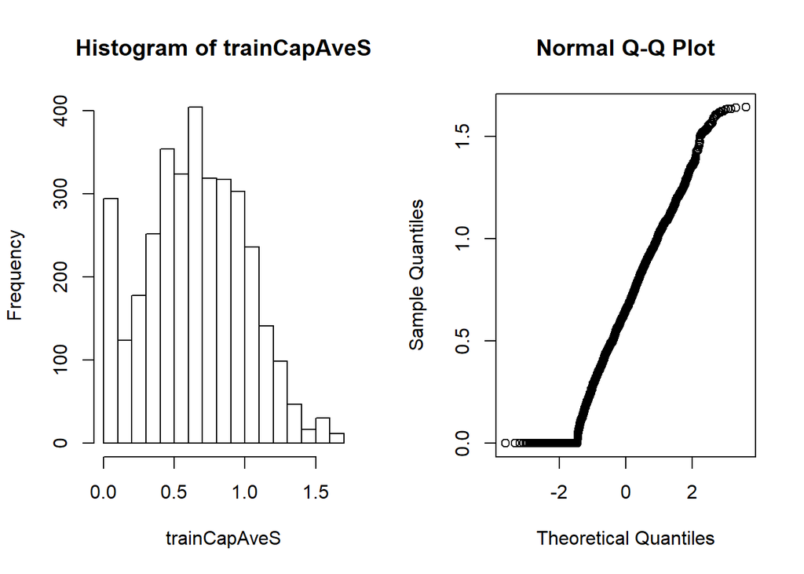

```r
preObj <- preProcess(training[,-58],method=c("BoxCox"))
trainCapAveS <- predict(preObj,training[,-58])$capitalAve
par(mfrow=c(1,2)); hist(trainCapAveS); qqnorm(trainCapAveS)
```

From both histogram and Q-Q plot we can see that Box-cox transformation doesn’t solve the entire problem. We still see some data points stacked at 0.0, which deviates from normality. Those are the points that don’t alight with the 45 degree line on Q-Q plot.

### Standardizing - Imputing data

**knnImpute (k-nearest neighbors computation)**  
Impute missing data by finding the k closest neighbors to the observation with missing data and then imputing them based on the the non-missing values in the neighbors, typically by taking the mean of the k neigbhors.

```r
set.seed(13343)
# Make some values NA
training$capAve <- training$capitalAve
selectNA <- rbinom(dim(training)[1],size=1,prob=0.05)==1
training$capAve[selectNA] <- NA
# Impute and standardize
preObj <- preProcess(training[,-58],method="knnImpute")
capAve <- predict(preObj,training[,-58])$capAve
# Standardize true values
capAveTruth <- training$capitalAve
capAveTruth <- (capAveTruth-mean(capAveTruth))/sd(capAveTruth)
# Compare before and after imputation
# All the quantiles are pretty close to zero. knnImpute worked pretty well.
quantile(capAve - capAveTruth)
```

```
##            0%           25%           50%           75%          100%
## -4.3142813242 -0.0007442054 -0.0002592231  0.0007811858  1.0069601406
```

```r
quantile((capAve - capAveTruth)[selectNA])
```

```
##           0%          25%          50%          75%         100%
## -4.314281324 -0.012000717  0.001214218  0.016868457  1.006960141
```

```r
quantile((capAve - capAveTruth)[!selectNA])
```

```
##            0%           25%           50%           75%          100%
## -0.0011248758 -0.0007184661 -0.0002602391  0.0007019359  0.7449756361
```

### Covariate creation

- Level 1: From raw data to covariate
  - Depends heavily on application
  - Trade-off between summarization vs. information loss
  - Example: text files - freq of words, phrases, capital letters
- Level 2: Transforming tidy covariates
  - More necessary for some methods (regression, svms) than for others (classification trees).
  - Should be done only on the training set.
  - The best approach is through exploratory analysis (plotting, tables)
  - New covariates should be added to data frames.

```r
data(spam)
spam$capitalAveSq <- spam$capitalAve^2
```

### dummy variables

dummyVars converts factor qualitative variables to quantitative variables.

```r
data(Wage)
inTrain <- createDataPartition(y=Wage$wage, p=0.7, list=FALSE)
training <- Wage[inTrain,]
testing <- Wage[-inTrain,]
table(training$jobclass)
```

```
##
##  1. Industrial 2. Information
##           1051           1051
```

```r
dummies <- dummyVars(wage~jobclass, data=training)
head(predict(dummies, newdata=training))
```

```
##        jobclass.1. Industrial jobclass.2. Information
## 86582                       0                       1
## 161300                      1                       0
## 155159                      0                       1
## 11443                       0                       1
## 376662                      0                       1
## 450601                      1                       0
```

### Removing zero covariates

nearZeroVar gets variables that has near zero variability. These near zero variables are meaningless and helpful to throw away.

```r
nsv <- nearZeroVar(training, saveMetrics =TRUE)
nsv
```

```
##            freqRatio percentUnique zeroVar   nzv
## year        1.037356    0.33301618   FALSE FALSE
## age         1.027027    2.85442436   FALSE FALSE
## maritl      3.272931    0.23786870   FALSE FALSE
## race        8.938776    0.19029496   FALSE FALSE
## education   1.389002    0.23786870   FALSE FALSE
## region      0.000000    0.04757374    TRUE  TRUE
## jobclass    1.000000    0.09514748   FALSE FALSE
## health      2.468647    0.09514748   FALSE FALSE
## health_ins  2.352472    0.09514748   FALSE FALSE
## logwage     1.061728   19.17221694   FALSE FALSE
## wage        1.061728   19.17221694   FALSE FALSE
```

### Spline basis

```r
bsBasis <- bs(training$age, df=3)
head(bsBasis)
```

```
##              1          2           3
## [1,] 0.2368501 0.02537679 0.000906314
## [2,] 0.4163380 0.32117502 0.082587862
## [3,] 0.4308138 0.29109043 0.065560908
## [4,] 0.3625256 0.38669397 0.137491189
## [5,] 0.3063341 0.42415495 0.195763821
## [6,] 0.4241549 0.30633413 0.073747105
```

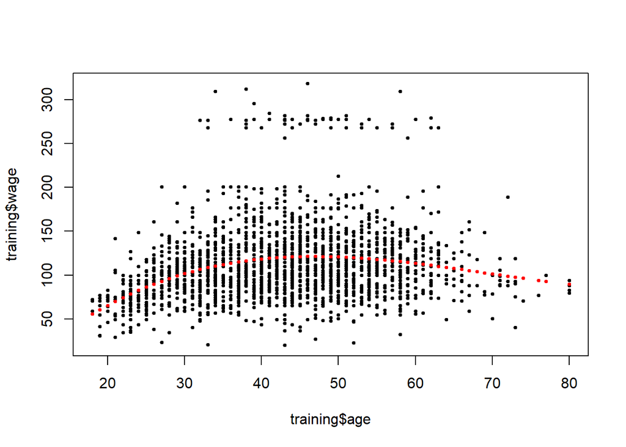

```r
lm1 <- lm(wage~bsBasis, data=training)
plot(training$age, training$wage, pch=19, cex=0.5)
points(training$age, predict(lm1, newdata=training), col="red", pch=19, cex=0.5)
```

```r
head(predict(bsBasis, age=testing$age))
```

```
##              1          2           3
## [1,] 0.2368501 0.02537679 0.000906314
## [2,] 0.4163380 0.32117502 0.082587862
## [3,] 0.4308138 0.29109043 0.065560908
## [4,] 0.3625256 0.38669397 0.137491189
## [5,] 0.3063341 0.42415495 0.195763821
## [6,] 0.4241549 0.30633413 0.073747105
```

### Preprocessing with Principal Components Analysis (PCA)

Let’s first observe the correlation between predictors. The example below will show variables with correlation higher than 0.8.

```r
data(spam)
inTrain<-createDataPartition(y=spam$type, p=0.75, list=FALSE)
training <- spam[inTrain,]
testing <- spam[inTrain,]
M <- abs(cor(training[,-58]))
diag(M)<-0
which(M > 0.8, arr.ind=T)
```

```
##        row col
## num415  34  32
## direct  40  32
## num857  32  34
## direct  40  34
## num857  32  40
## num415  34  40
```

```r
names(spam[c(34,32)])
```

```
## [1] "num415" "num857"
```

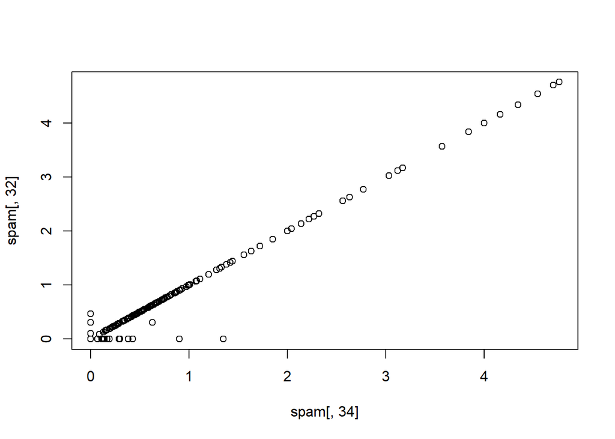

```r
#The variable num 415 is highly correlated to num 857
plot(spam[,34], spam[,32])
```

### Basic PCA idea

- We might not need every predictor
- A weighted combination of predictors might be better
- We should pick this combination to capture the “most information” possible
- Benefits:
  - Reduced number of predictors
  - Reduced noise (due to averaging)

### We could rotate the plot

$$X = 0.71 * num415+0.71*num857$$
$$X = 0.71 * num415-0.71*num857$$

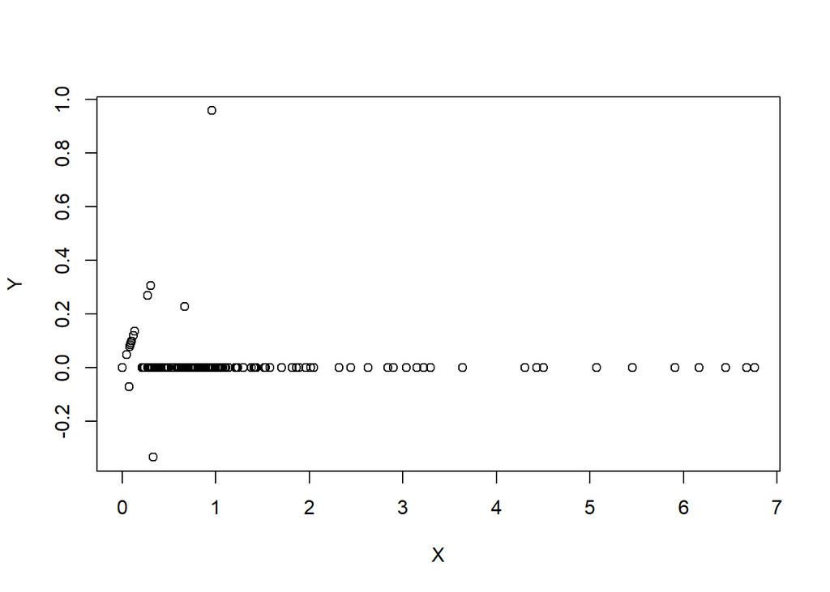

```r
X <- 0.71*training$num415 + 0.71*training$num857
Y <- 0.71*training$num415 - 0.71*training$num857
plot(X,Y)
```

- We can see that most of the variability is happening in x-axis.
- So, adding the two variables captures more information than subtracting those two.
- Take the addition of two variables as the predictor variable.

### Related problems

You have multivariable variables $X_1,...,X_n$ so $X_1 = (X11,...,X_{1m})$

- Find a new set of multivariate variables that are uncorrelated and explain as much variance as possible
- If you put all the variables together in one matrix, find the best matrix created with fewer variables (lower rank) that explains the original data.
- The first goal is statistical and the second goal is data compression.

### Related solutions - PCA/SVD

## SVD (Singular value decomposition)

If $X$ is a matrix with each variable in a column and each observation in a row then the SVD is a matrix decomposition
$$X=UDV^T$$
where the column of $U$ are orthogonal (left signular vectors), the columns of $V$ are orthogonal (right singular vectors) and $D$ is a diagonal matrix (singular values). ##PCA##
The principal components are equal to the right singular values if you first scale (subtract the mean, divide by the standard deviation) the variables.

### Principal components in R - prcomp

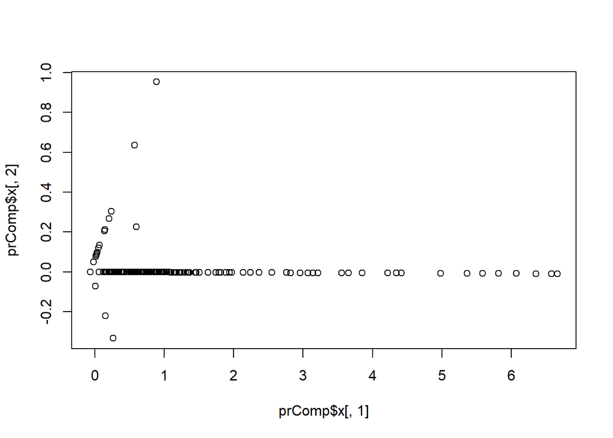

```r
smallSpam <- spam[, c(34,32)]
prComp <- prcomp(smallSpam)
plot(prComp$x[,1], prComp$x[,2])
```

```r
prComp$rotation
```

```
##              PC1        PC2
## num415 0.7080625  0.7061498
## num857 0.7061498 -0.7080625
```

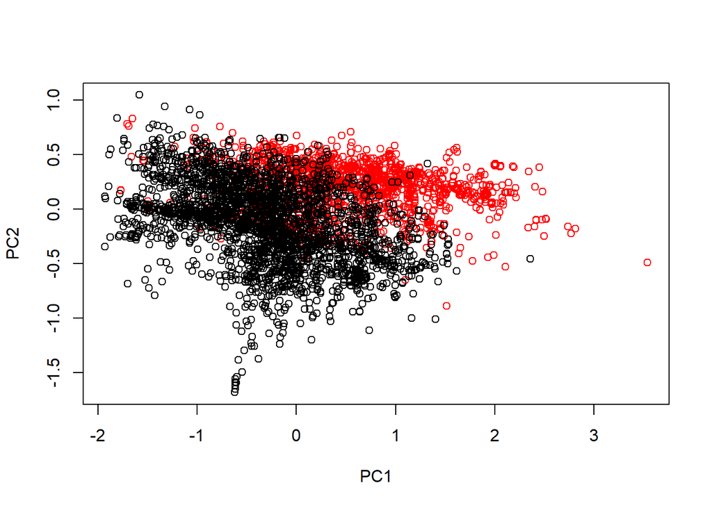

```r
# PCA with SPAM dataset
typeColor <- ((spam$type=="spam")*1+1)
prComp <- prcomp(log10(spam[,-58]+1))
plot(prComp$x[,1], prComp$x[,2], col=typeColor, xlab="PC1", ylab="PC2")
```

- The x-axis is the first principal component and y-axis is the second. These components can be combination of the SPAM dataset covariates.
- The order of principal component is the order of significance.
- Along the x-axis (PC1) we can see the separation between SPAM and HAM messages.

### PCA with caret

```r
preProc <- preProcess(log10(training[,-58]+1), method="pca", pcaComp=2)
trainPC <- predict(preProc, log10(training[,-58]+1))
modelFit <- train(y=training$type, x=trainPC, method="glm")
testPC <- predict(preProc, log10(testing[,-58]+1))
# Use confusionMatrix to get accuracy
confusionMatrix(testing$type, predict(modelFit,testPC))
```

```
## Confusion Matrix and Statistics
##
##           Reference
## Prediction nonspam spam
##    nonspam    1962  129
##    spam        198 1162
##
##                Accuracy : 0.9052
##                  95% CI : (0.895, 0.9148)
##     No Information Rate : 0.6259
##     P-Value [Acc > NIR] : < 2.2e-16
##
##                   Kappa : 0.7998
##  Mcnemar's Test P-Value : 0.0001696
##
##             Sensitivity : 0.9083
##             Specificity : 0.9001
##          Pos Pred Value : 0.9383
##          Neg Pred Value : 0.8544
##              Prevalence : 0.6259
##          Detection Rate : 0.5685
##    Detection Prevalence : 0.6059
##       Balanced Accuracy : 0.9042
##
##        'Positive' Class : nonspam
##
```

```r
#You don't have to use predict function if you use preProcess argument on train
modelFit2<- train(y=training$type, method="glm", preProcess="pca", x=training)
confusionMatrix(testing$type, predict(modelFit2,testing))
```

```
## Confusion Matrix and Statistics
##
##           Reference
## Prediction nonspam spam
##    nonspam    2091    0
##    spam          0 1360
##
##                Accuracy : 1
##                  95% CI : (0.9989, 1)
##     No Information Rate : 0.6059
##     P-Value [Acc > NIR] : < 2.2e-16
##
##                   Kappa : 1
##  Mcnemar's Test P-Value : NA
##
##             Sensitivity : 1.0000
##             Specificity : 1.0000
##          Pos Pred Value : 1.0000
##          Neg Pred Value : 1.0000
##              Prevalence : 0.6059
##          Detection Rate : 0.6059
##    Detection Prevalence : 0.6059
##       Balanced Accuracy : 1.0000
##
##        'Positive' Class : nonspam
##
```

### Notes on PCA

- Most useful for linear-type models
- Can make it harder to interpret predictors
- Watch out for outliers
  - Perform explanatory analysis
  - Transform first (with logs/Box cox)
  - Plot predictors to identify problems

### Predicting with regression

- Fit a simple regression model
- Plug in new covariates and multiply by the coefficients
- Useful when the linear model is correct
- Pros: easy to implement and interpret
- Cons: poor performance in nonlinear settings.

### Example: Old faithful eruptions

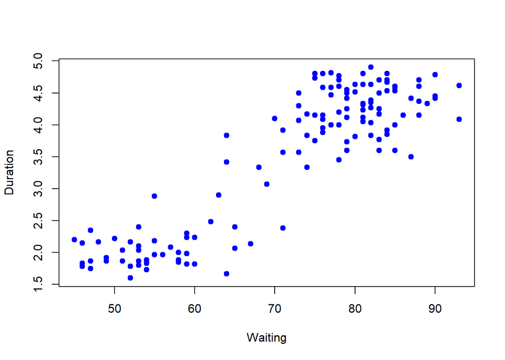

```r
data(faithful)
set.seed(333)
inTrain <- createDataPartition(y=faithful$waiting, p=0.5, list=FALSE)
trainFaith <- faithful[inTrain,]
testFaith <- faithful[-inTrain,]
plot(trainFaith$waiting, trainFaith$eruptions, pch=19, col="blue", xlab="Waiting", ylab="Duration")
```

### Fit a linear model

$$ED_i = b_0+b_1WT_i+e_i$$

```r
lm1 <- lm(eruptions~waiting, data=trainFaith)
summary(lm1)
```

```
##
## Call:
## lm(formula = eruptions ~ waiting, data = trainFaith)
##
## Residuals:
##      Min       1Q   Median       3Q      Max
## -1.26990 -0.34789  0.03979  0.36589  1.05020
##
## Coefficients:
##              Estimate Std. Error t value Pr(>|t|)
## (Intercept) -1.792739   0.227869  -7.867 1.04e-12 ***
## waiting      0.073901   0.003148  23.474  < 2e-16 ***
## ---
## Signif. codes:  0 '***' 0.001 '**' 0.01 '*' 0.05 '.' 0.1 ' ' 1
##
## Residual standard error: 0.495 on 135 degrees of freedom
## Multiple R-squared:  0.8032, Adjusted R-squared:  0.8018
## F-statistic:   551 on 1 and 135 DF,  p-value: < 2.2e-16
```

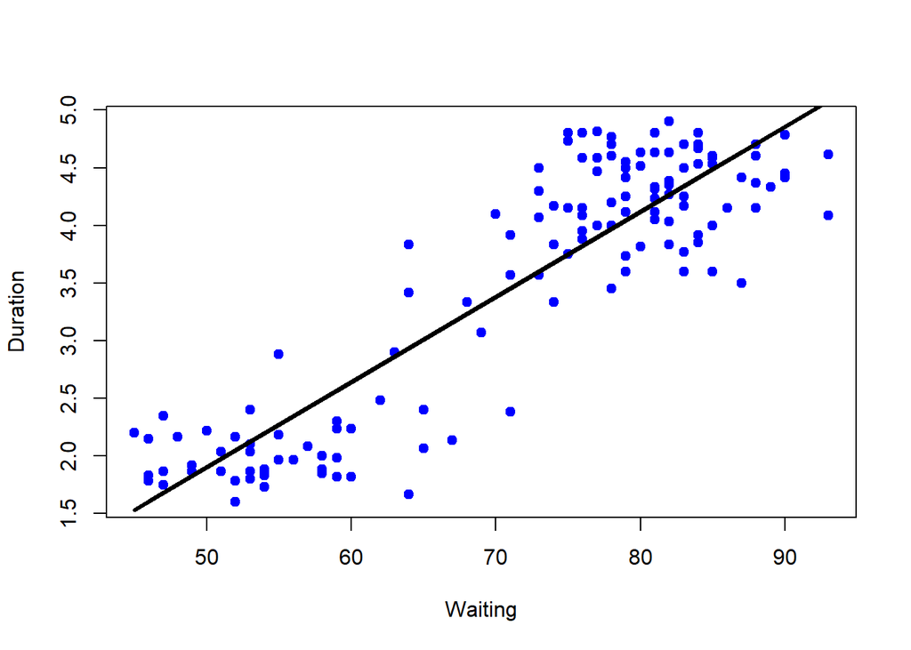

```r
plot(trainFaith$waiting, trainFaith$eruptions, pch=19, col="blue", xlab="Waiting", ylab="Duration")
lines(trainFaith$waiting, lm1$fitted.values, lwd=3)
```

```r
#Predicting a new value
coef(lm1)[1] + coef(lm1)[2]*80
```

```
## (Intercept)
##    4.119307
```

```r
newdata <- data.frame(waiting=80)
predict(lm1, newdata)
```

```
##        1
## 4.119307
```

### Plot predictions - training and testing

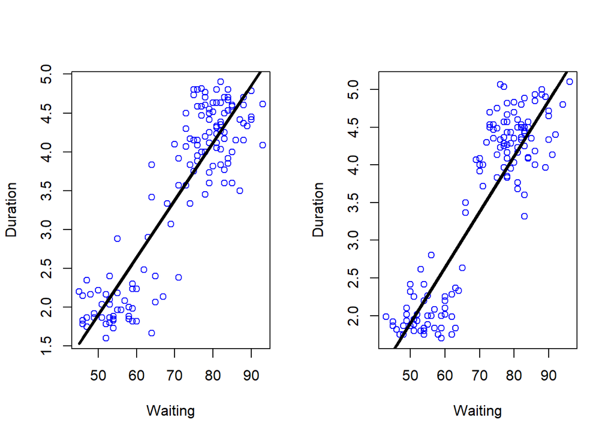

```r
par(mfrow=c(1,2))
plot(trainFaith$waiting, trainFaith$eruptions, pach=19, col="blue", xlab="Waiting", ylab="Duration")
lines(trainFaith$waiting, predict(lm1), lwd=3)
plot(testFaith$waiting, testFaith$eruptions, pach=19, col="blue", xlab="Waiting", ylab="Duration")
lines(testFaith$waiting, predict(lm1, newdata=testFaith), lwd=3)
```

### Get training/test set errors

```r
#Calculate RMSE on training
sqrt(sum((lm1$fitted.values-trainFaith$eruptions)^2))
```

```
## [1] 5.75186
```

```r
#Calculate RMSE on testing
sqrt(sum((predict(lm1, newdata=testFaith)-testFaith$eruptions)^2))
```

```
## [1] 5.838559
```

### Prediction intervals

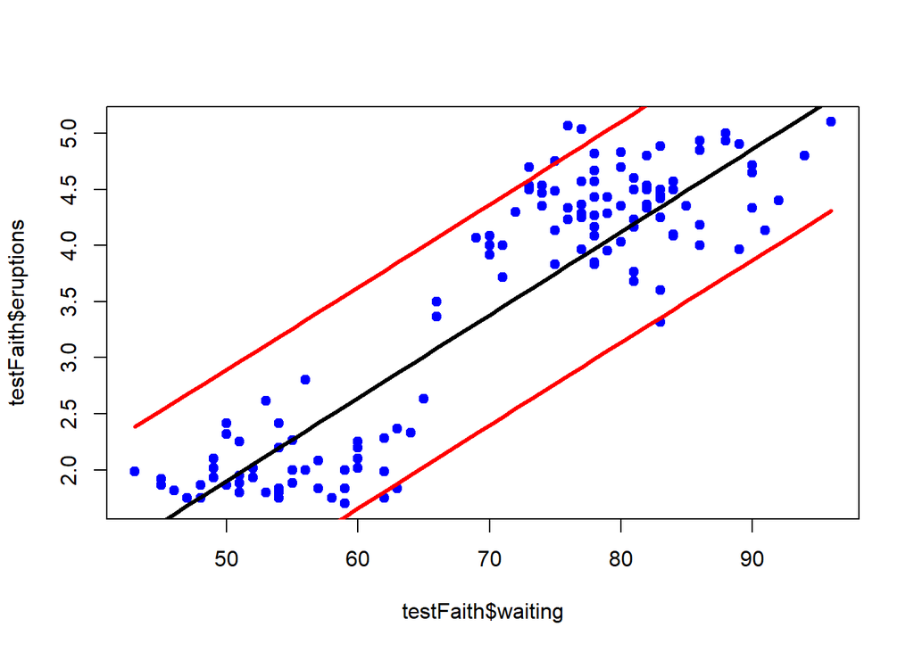

```r
pred1 <- predict(lm1, newdata=testFaith, interval="prediction")
ord <- order(testFaith$waiting)
plot(testFaith$waiting, testFaith$eruptions, pch=19, col="blue")
matlines(testFaith$waiting[ord], pred1[ord,], type="l",col=c(1,2,2), lty=c(1,1,1), lwd=3)
```

### Same process with caret

```r
modFit <- train(eruptions~waiting, data=trainFaith, method="lm")
summary(modFit$finalM)
```

```
##
## Call:
## lm(formula = .outcome ~ ., data = dat)
##
## Residuals:
##      Min       1Q   Median       3Q      Max
## -1.26990 -0.34789  0.03979  0.36589  1.05020
##
## Coefficients:
##              Estimate Std. Error t value Pr(>|t|)
## (Intercept) -1.792739   0.227869  -7.867 1.04e-12 ***
## waiting      0.073901   0.003148  23.474  < 2e-16 ***
## ---
## Signif. codes:  0 '***' 0.001 '**' 0.01 '*' 0.05 '.' 0.1 ' ' 1
##
## Residual standard error: 0.495 on 135 degrees of freedom
## Multiple R-squared:  0.8032, Adjusted R-squared:  0.8018
## F-statistic:   551 on 1 and 135 DF,  p-value: < 2.2e-16
```

### Predicting with Regression Multiple Covariates

```r
data(Wage)
Wage <- subset(Wage, select=-c(logwage))
summary(Wage)
```

```
##       year           age                     maritl           race
##  Min.   :2003   Min.   :18.00   1. Never Married: 648   1. White:2480
##  1st Qu.:2004   1st Qu.:33.75   2. Married      :2074   2. Black: 293
##  Median :2006   Median :42.00   3. Widowed      :  19   3. Asian: 190
##  Mean   :2006   Mean   :42.41   4. Divorced     : 204   4. Other:  37
##  3rd Qu.:2008   3rd Qu.:51.00   5. Separated    :  55
##  Max.   :2009   Max.   :80.00
##
##               education                     region
##  1. < HS Grad      :268   2. Middle Atlantic   :3000
##  2. HS Grad        :971   1. New England       :   0
##  3. Some College   :650   3. East North Central:   0
##  4. College Grad   :685   4. West North Central:   0
##  5. Advanced Degree:426   5. South Atlantic    :   0
##                           6. East South Central:   0
##                           (Other)              :   0
##            jobclass               health      health_ins
##  1. Industrial :1544   1. <=Good     : 858   1. Yes:2083
##  2. Information:1456   2. >=Very Good:2142   2. No : 917
##
##
##
##
##
##       wage
##  Min.   : 20.09
##  1st Qu.: 85.38
##  Median :104.92
##  Mean   :111.70
##  3rd Qu.:128.68
##  Max.   :318.34
##
```

```r
inTrain<- createDataPartition(y=Wage$wage, p=0.7, list=FALSE)
training <- Wage[inTrain,]
testing <- Wage[-inTrain,]
```

### Fit a linear model

$$ED_i = b_0+b_1age+b_2I(Jobclass_i =Information)+\sum_{k=1}^{4}r_kI(education_i=level_k$$

- $b_0$: intercept term. The baseline level of wage.
- $b_1$: coefficient that explains the relationship with the age of the person and the wage
- $b_2$: coefficient that explains the relationship between the job class and the wage. $I=1$ if the jobclass is information, otherwise 0.
- $b_3$: the covariate is level indicator for different education level.

```r
modFit<- train(wage ~ age + jobclass + education,
               method = "lm",data=training)
finMod <- modFit$finalModel
print(modFit)
```

```
## Linear Regression
##
## 2102 samples
##    3 predictor
##
## No pre-processing
## Resampling: Bootstrapped (25 reps)
## Summary of sample sizes: 2102, 2102, 2102, 2102, 2102, 2102, ...
## Resampling results:
##
##   RMSE      Rsquared  MAE
##   35.79066  0.248127  24.68782
##
## Tuning parameter 'intercept' was held constant at a value of TRUE
```

### Diagnostics

- Plot residuals vs fitted values

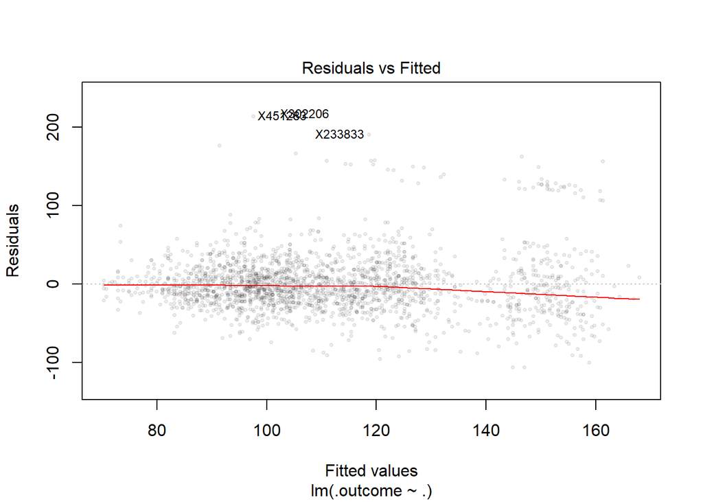

```r
plot(finMod, 1, pch=19, cex=0.5, col="#00000010")
```

The outliers are noted. We can see the residual plot around zero line.

- Color by variables not used in the model

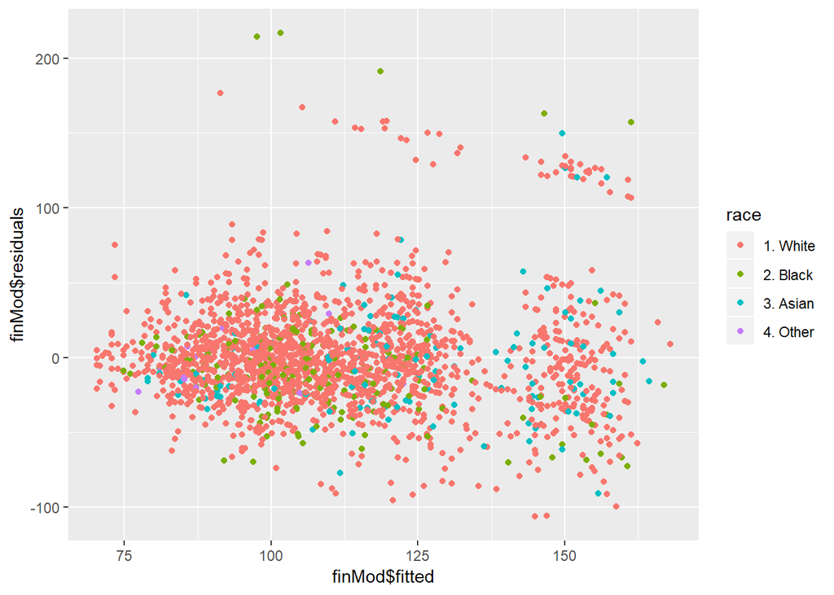

```r
qplot(finMod$fitted, finMod$residuals, colour=race, data=training)
```

We can also attempted to exaplain the residual plot by coloring it by race

- Plot by index

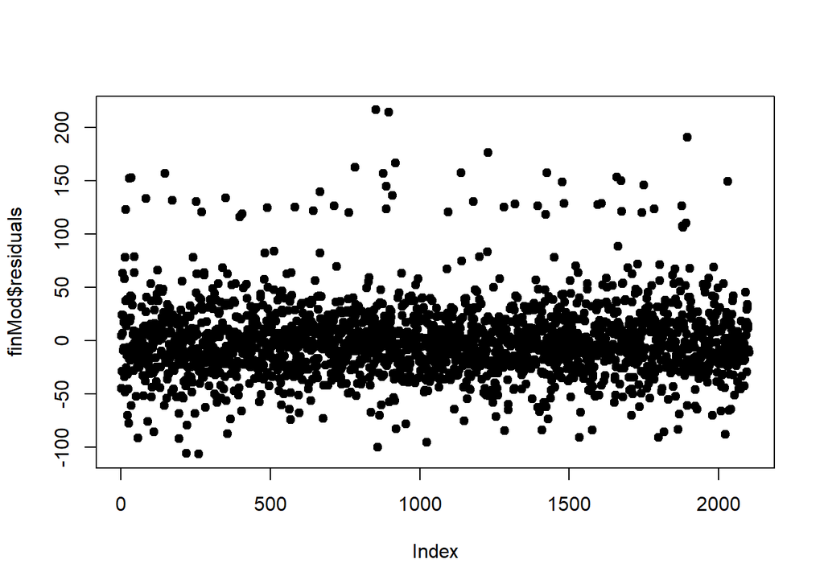

```r
plot(finMod$residuals, pch=19)
```